# model diagnostics

Eldon

July 14, 2022

#### Model diagnostics

##### Assumptions

Linear mixed effects models are based on the following assumptions;

1. Independent variables measured without an error (Fixed x)
2. Errors are normally distributed
3. Errors are independent
4. Errors have constant variance
5. Relationship between X and Y is linear

We use the graphs to determine weather the model assumptions are fulfilled or we can improve it.

1. Turkey-Anscombe plot

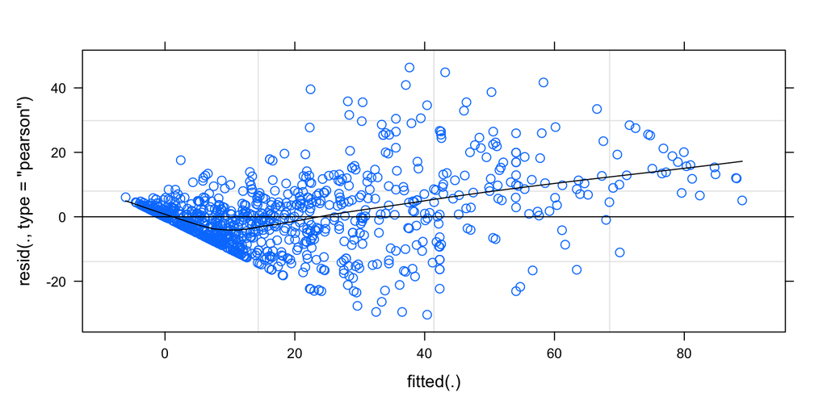

2. Quantile-quantile plots

We assumed that both the errors and the random intercepts come from a normal distribution we test this using Q-Q plot

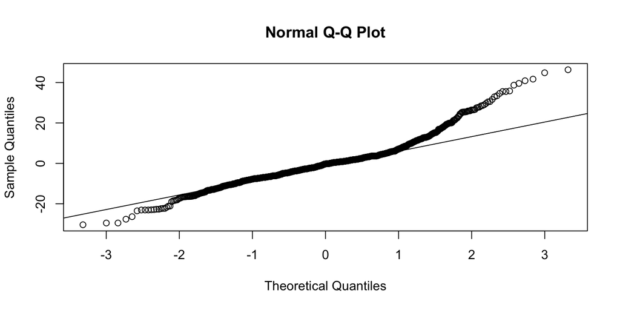

###### 3.Residuals against predictors

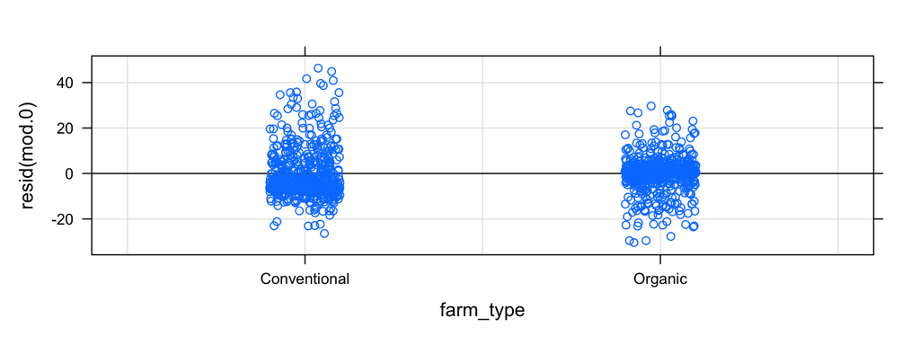

The graph above indicates that residuals in the conventional farms have a higher variance as compared to organic farms, nevertheless, the is no dramatic difference between two farm types

We now plot the residuals against the host. In order to better identify deviations from linearity we add a line connecting the average values at each age.

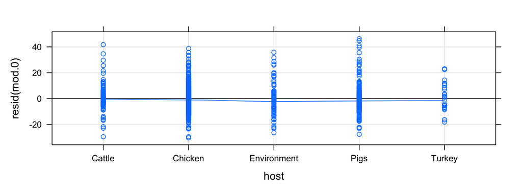

There seems to be no clear deviation from zero. This implies that at this stage there is no evidence against percent resistance of modelled hosts. In addition, the variance of the residuals seems to be constant along the five time points (i.e homoscedasticity).

We use the dot plot below to check whether all studies have similar variences

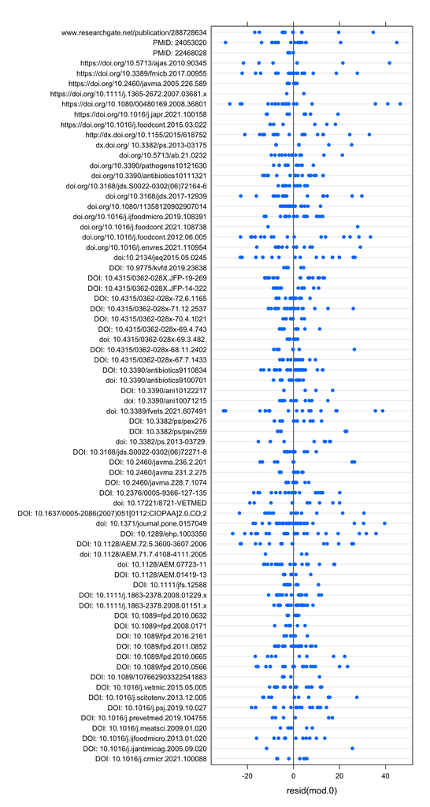

I don’t think there is a striking difference in variability among the studies. I would like to hear your thoughts on this plot.